# Predicting how well an exercise is performed

Jordan Strauss

April 24, 2016

# Summary

We will try to determine how well people perform a weightlifting excersize (dumbell curls) using data from accelerometers attached at different locations to their bodies

Load library’s set seed

```r
library(caret);library(randomForest)
set.seed(12345)
```

# Data import

Download the dataset from the web and read into R. Read blank entries as NAs

```r
download.file("https://d396qusza40orc.cloudfront.net/predmachlearn/pml-training.csv", "MLCTrain.csv")
TrainMaster<- read.csv("MLCTrain.csv", header=T, na.strings=c("","NA"))
```

# Exploratory Data Analysis

Check out the dataset by using summary and examining the class of the columns

```r
#summary(TrainMaster)
#lapply(TrainMaster,Class)
```

The response field is classe and it is spuriously correlated to the index field x. It is also clear that there are a number of columns which are almost entirely NAs, except when the “new_window” column is equal to yes. And there are a number of columns such as timestamps, user names and entry numbers which are not related to movements and should not be considered when training our models.

# Cleaning the data

Filter the data such that the dataset only includes the predictor variables we want and the response

```r
#Filter out new window =yes
TrainMaster<-TrainMaster[TrainMaster$new_window!="yes",]
#Filter out Columns consisting of all NAs
TrainMaster <- TrainMaster[,colSums(is.na(TrainMaster))<nrow(TrainMaster)]
#Filter out Columns which are not the response or accellerometer data
TrainMaster<-TrainMaster[,-c(1,3,4,5,6,7)]
```

# Build Model

We split the data set into a training and a test set. Since this is a classification problem and we the problem is straightfoward enough such that interpretability is not a major concern, we fit a model using Random Forest

```r
intrain<-createDataPartition(TrainMaster$classe,p=.7,list = FALSE)
training<-TrainMaster[intrain,]
testing<-TrainMaster[-intrain,]
modFit1<-randomForest(classe~.,data=training,importance=TRUE)
modFit1
```

```
##
## Call:
##  randomForest(formula = classe ~ ., data = training, importance = TRUE)
##                Type of random forest: classification
##                      Number of trees: 500
## No. of variables tried at each split: 7
##
##         OOB estimate of  error rate: 0.53%
## Confusion matrix:
##      A    B    C    D    E  class.error
## A 3829    1    0    0    0 0.0002610966
## B   15 2584    4    0    0 0.0072992701
## C    0   14 2328    5    0 0.0080954410
## D    0    0   22 2180    1 0.0104403087
## E    0    0    2    7 2461 0.0036437247
```

Random forest fits a model with 500 trees,and an expected out of sample error of ~.5%

Plot variable importance

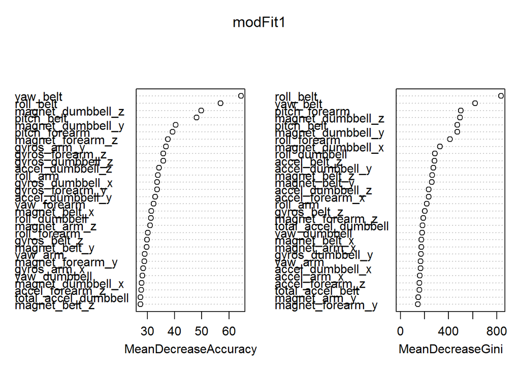

```r
varImpPlot(modFit1)
```

# Cross Validation

Predict values on the testing set and check accuracy

```r
pred1<-predict(modFit1,testing)
confusionMatrix(pred1,testing$classe)
```

```
## Confusion Matrix and Statistics
##
##           Reference
## Prediction    A    B    C    D    E
##          A 1641   17    0    0    0
##          B    0 1095    1    0    0
##          C    0    3 1004    9    0
##          D    0    0    0  934    4
##          E    0    0    0    1 1054
##
## Overall Statistics
##
##                Accuracy : 0.9939
##                  95% CI : (0.9916, 0.9958)
##     No Information Rate : 0.2847
##     P-Value [Acc > NIR] : < 2.2e-16
##
##                   Kappa : 0.9923
##  Mcnemar's Test P-Value : NA
##
## Statistics by Class:
##
##                      Class: A Class: B Class: C Class: D Class: E
## Sensitivity            1.0000   0.9821   0.9990   0.9894   0.9962
## Specificity            0.9959   0.9998   0.9975   0.9992   0.9998
## Pos Pred Value         0.9897   0.9991   0.9882   0.9957   0.9991
## Neg Pred Value         1.0000   0.9957   0.9998   0.9979   0.9992
## Prevalence             0.2847   0.1935   0.1744   0.1638   0.1836
## Detection Rate         0.2847   0.1900   0.1742   0.1621   0.1829
## Detection Prevalence   0.2877   0.1902   0.1763   0.1628   0.1831
## Balanced Accuracy      0.9979   0.9909   0.9982   0.9943   0.9980
```

Model shows an accuary of >99%

# Course Project Prediction Quiz

Download and import test data, predict classe using random forest model

```r
download.file("https://d396qusza40orc.cloudfront.net/predmachlearn/pml-testing.csv", "MLCTest.csv")
test<-read.csv("MLCTest.csv",header = T,na.strings=c("","NA"))
predict(modFit1,test)
```

```
##  1  2  3  4  5  6  7  8  9 10 11 12 13 14 15 16 17 18 19 20
##  B  A  B  A  A  E  D  B  A  A  B  C  B  A  E  E  A  B  B  B
## Levels: A B C D E
```